# Instagram Followers Analysis

Marina Gómez Rey

# Introduction

In the age of social media, understanding the dynamics of online interactions has become increasingly important. One aspect that intrigues many is how to become more popular in the platform and gain followers. For that reason, in this study, this is going to be studied by examining how the number of followers is related to two key factors: the number of accounts a user follows and the number of close friends they have. Particularly, this is studied on Instagram, which has the close Friends facility available. With it, only the selected people are able to see some posts of the user.

## Data collection

In order to make this project possible I created a Google forms with this link, in which three questions were asked:

- How many followers do you have?
- How many people do you follow?
- How many people do you have in close friends?

Link to the form: https://docs.google.com/forms/d/e/1FAIpQLScuJE_SDkGRMfI21tcmbEOE8-tAHEVNpdmwu7pzh-nJe8Bmkg/viewform?usp=sf_link

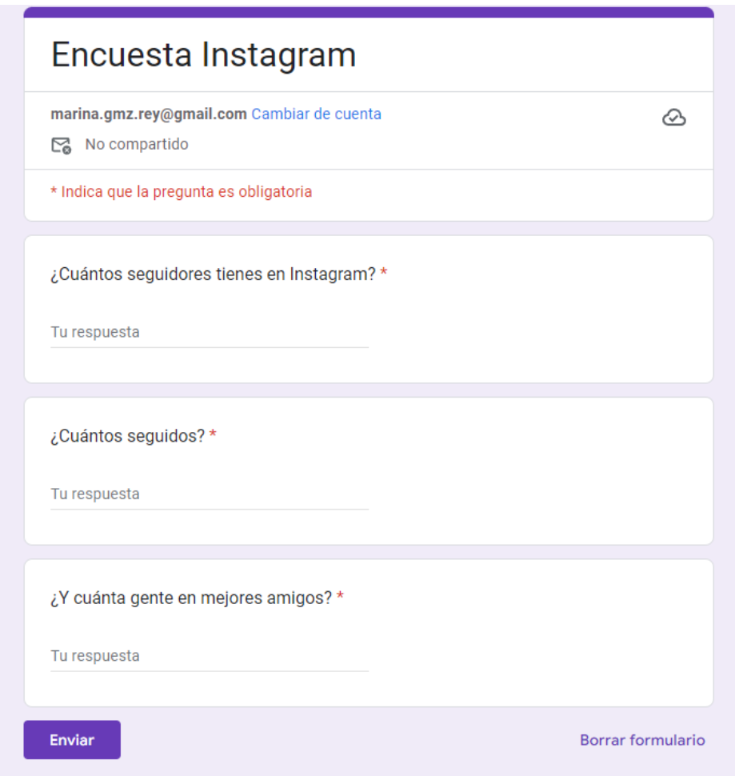

Form Picture

The form was shared among friends, who kindly responded to it. The data from these responses were collected into a CSV file for analysis. This data provides a snapshot of social interactions on Instagram among a specific group of users, which will be analyzed to identify patterns and relationships.

[Link to the form](https://docs.google.com/forms/d/e/1FAIpQLScuJE_SDkGRMfI21tcmbEOE8-tAHEVNpdmwu7pzh-nJe8Bmkg/viewform?usp=sf_link)

## Data Exploration and Preprocessing

Let’s tsart by loading the data and showing it without any further change.

```r
# Load the data and show it
data <- read.csv('instagram.csv')
head(data, n = 10)
```

```
##                  Marca.temporal X.Cuántos.seguidores.tienes.en.Instagram.
## 1  2024/04/18 6:19:12 p. m. EET                                       300
## 2  2024/04/18 6:19:15 p. m. EET                                        71
## 3  2024/04/18 6:20:23 p. m. EET                                       377
## 4  2024/04/18 6:20:32 p. m. EET                                       421
## 5  2024/04/18 6:20:54 p. m. EET                                       950
## 6  2024/04/18 6:21:04 p. m. EET                                      1171
## 7  2024/04/18 6:21:39 p. m. EET                                       128
## 8  2024/04/18 6:22:04 p. m. EET                                       893
## 9  2024/04/18 6:22:05 p. m. EET                                       894
## 10 2024/04/18 6:22:45 p. m. EET                                      1386
##    X.Cuántos.seguidos. X.Y.cuánta.gente.en.mejores.amigos.
## 1                  300                                  10
## 2                  135                                   0
## 3                  231                                  31
## 4                  540                                  61
## 5                 1300                                  70
## 6                 1131                                  77
## 7                  341                                   1
## 8                  839                                  20
## 9                 1164                                  92
## 10                2375                                  60
```

The date and time when the form was answered is not relevant and the column names are too long so firstly let’s assess this.

```r
data <- data[, -which(names(data) == "Marca.temporal")]
colnames(data) <- c("Followers", "Following", "Close.Friends")
head(data, n = 10)
```

```
##    Followers Following Close.Friends
## 1        300       300            10
## 2         71       135             0
## 3        377       231            31
## 4        421       540            61
## 5        950      1300            70
## 6       1171      1131            77
## 7        128       341             1
## 8        893       839            20
## 9        894      1164            92
## 10      1386      2375            60
```

Let’s look for empty values. Also, on line 85 there is a cell containing 2.3 millones, that has to be changed to a correct number. However, it will be a huge outlier so it will be better to erase it directly. Also erase all values whose three columns are 0, as that means they do not have instagram. Finally, convert all to integers.

```r
print(any(is.na(data))) # There are no empty values
```

```
## [1] FALSE
```

```r
data <- data[-85,]
data$Followers <- as.integer(data$Followers)
data$Following <- as.integer(data$Following)
data$Close.Friends <- as.integer(data$Close.Friends)
data <- data[rowSums(data != 0) > 0, ] # erase columns with all as 0s
```

Finally, let’s show how the whole dataset looks right now.

```r
data
```

```
##    Followers Following Close.Friends
## 1        300       300            10
## 2         71       135             0
## 3        377       231            31
## 4        421       540            61
## 5        950      1300            70
## 6       1171      1131            77
## 7        128       341             1
## 8        893       839            20
## 9        894      1164            92
## 10      1386      2375            60
## 11       784       257            38
## 12      2228      1525            39
## 13       847       830            61
## 14       180       112            12
```

[output cut: 73 more lines]

In order to see if there is any relationship between the data, or they follow any pattern, let’s make some graphs and see the correlation

## Plots

Now let’s see the scatterplots for all the variables:

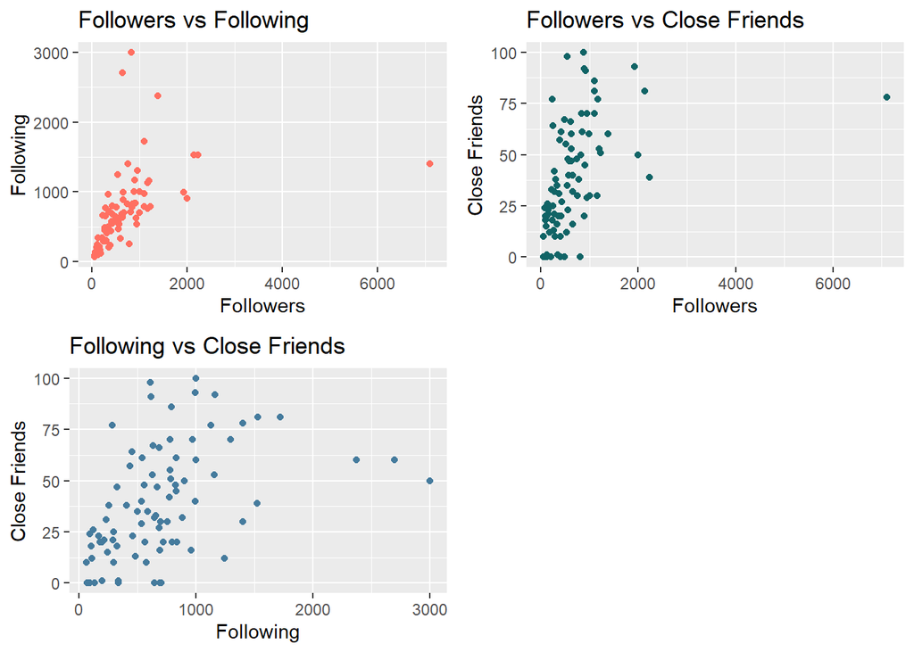

```r
library(ggplot2)
library(gridExtra)

# Create scatter plots to show the relationship between variables
scatter_plot_followers_following <- ggplot(data, aes(x = Followers, y = Following)) +
  geom_point(color = "#FF6F61") +  # Coral color
  labs(title = "Followers vs Following",
       x = "Followers",
       y = "Following")

scatter_plot_followers_friends <- ggplot(data, aes(x = Followers, y = Close.Friends)) +
  geom_point(color = "#116466") +  # Aqua color
  labs(title = "Followers vs Close Friends",
       x = "Followers",
       y = "Close Friends")

scatter_plot_following_friends <- ggplot(data, aes(x = Following, y = Close.Friends)) +
  geom_point(color = "#457B9D") +  # Blue color
  labs(title = "Following vs Close Friends",
       x = "Following",
       y = "Close Friends")

# Display the scatter plots
grid.arrange(scatter_plot_followers_following, scatter_plot_followers_friends, scatter_plot_following_friends, ncol = 2)
```

There are some outliers that are not letting us see the data properly, so I will only keep the lines that on both Followers and Following are below 1500.

```r
data <- data[data$Following < 1500, ]
data <- data[data$Followers < 1500, ]
```

Now let’s see again the scatterplots without the outliers.

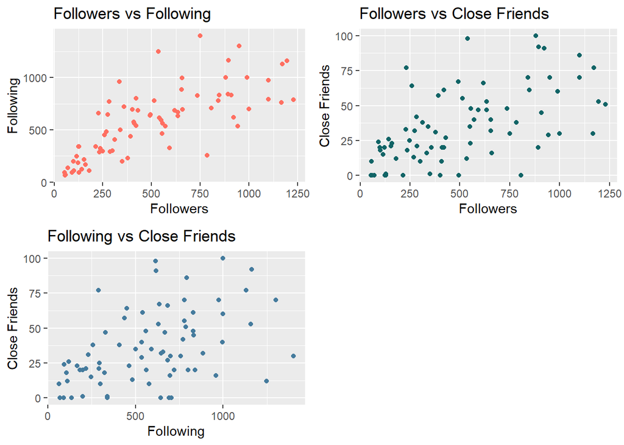

```r
# Create scatter plots to show the relationship between variables
scatter_plot_followers_following <- ggplot(data, aes(x = Followers, y = Following)) +
  geom_point(color = "#FF6F61") +  # Coral color
  labs(title = "Followers vs Following",
       x = "Followers",
       y = "Following")

scatter_plot_followers_friends <- ggplot(data, aes(x = Followers, y = Close.Friends)) +
  geom_point(color = "#116466") +  # Aqua color
  labs(title = "Followers vs Close Friends",
       x = "Followers",
       y = "Close Friends")

scatter_plot_following_friends <- ggplot(data, aes(x = Following, y = Close.Friends)) +
  geom_point(color = "#457B9D") +  # Blue color
  labs(title = "Following vs Close Friends",
       x = "Following",
       y = "Close Friends")

# Display the scatter plots
grid.arrange(scatter_plot_followers_following, scatter_plot_followers_friends, scatter_plot_following_friends, ncol = 2)
```

Now, the relationships are better seen. It can be seen that there is a kind of linear relationship in all relationships but it is more recognizable between Followers and Following, so they are the most related ones. However, to check this better, the correlations between the variables can be obtained.

```r
cor(data)
```

```
##               Followers Following Close.Friends
## Followers     1.0000000 0.7530121     0.5855995
## Following     0.7530121 1.0000000     0.4873309
## Close.Friends 0.5855995 0.4873309     1.0000000
```

The correlations show that, as it seemed, the value of followers and following is the highest, while following and close friends is the lowest. All values are positive, what means that the relationships are positive between the variables.

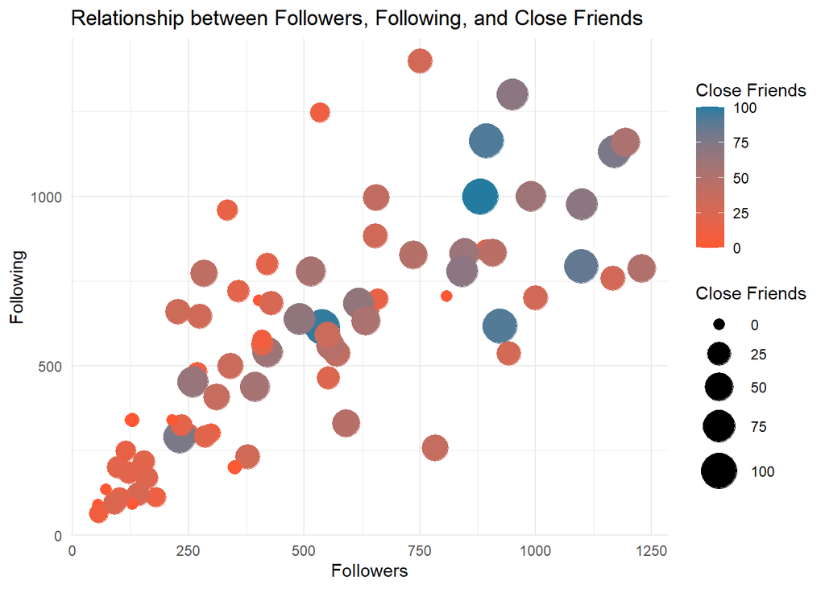

```r
color_intensity_plot <- ggplot(data, aes(x = Followers, y = Following, color = Close.Friends, size = Close.Friends)) +
  geom_point() +
  scale_color_gradient(low = "#FF5733", high = "#247BA0") +  # Color gradient from red to blue
  scale_size_continuous(range = c(3, 10)) +  # Adjust the range of dot sizes
  labs(title = "Relationship between Followers, Following, and Close Friends",
       x = "Followers",
       y = "Following",
       color = "Close Friends",
       size = "Close Friends") +
  theme_minimal()

# Display the scatter plot
color_intensity_plot
```

Once this is clear, let’s see the distributions of all the variables.

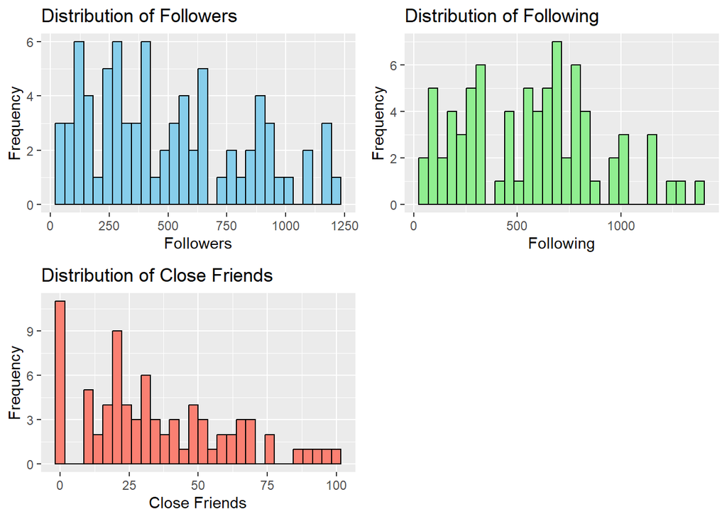

```r
followers_plot <- ggplot(data, aes(x = Followers)) +
  geom_histogram(fill = "skyblue", color = "black", bins = 30) +
  labs(title = "Distribution of Followers",
       x = "Followers",
       y = "Frequency")

following_plot <- ggplot(data, aes(x = Following)) +
  geom_histogram(fill = "lightgreen", color = "black", bins = 30) +
  labs(title = "Distribution of Following",
       x = "Following",
       y = "Frequency")

close_friends_plot <- ggplot(data, aes(x = Close.Friends)) +
  geom_histogram(fill = "salmon", color = "black", bins = 30) +
  labs(title = "Distribution of Close Friends",
       x = "Close Friends",
       y = "Frequency")

# Display the plots
grid.arrange(followers_plot, following_plot, close_friends_plot, ncol = 2)
```

The variables are not following any distribution very clearly. In the case of Following, it is kind of normal-ish, but close friends is more right-skewed and seems a little bit more Gamma. Regarding Followers, it has various bars that are peaks.

As the variable that we are going to study is Followers, and the distribution is not very clear, let’s make a non-specific number of components clustering to see how it is working.

## Clustering of the target variable

```r
library(mixAK)
kprior.unif <- list(priorK="uniform", Kmax=30)
nMCMC <- c(burn=5000, keep=100000, thin=15, info=5000)
RJModel <- NMixMCMC(y0=data$Followers, prior=kprior.unif, nMCMC=nMCMC,
                    scale=list(shift=0, scale=1),PED=F)
```

```
##
## Chain number 1
## ==============
## MCMC sampling started on Tue May 21 17:02:55 2024.
## Burn-in iteration 5000
## Iteration 100001500020000250003000035000400004500050000550006000065000700007500080000850009000095000100000105000
## MCMC sampling finished on Tue May 21 17:03:42 2024.
```

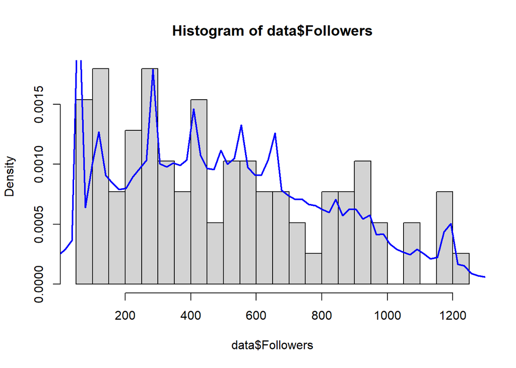

```r
# Predictive density
pdensRJ <- NMixPredDensMarg(RJModel, lgrid=125)
hist(data$Followers, probability = T, breaks = 30)
lines(pdensRJ$x$x1,pdensRJ$dens$"1", lwd=2, col="blue", type = "l")
```

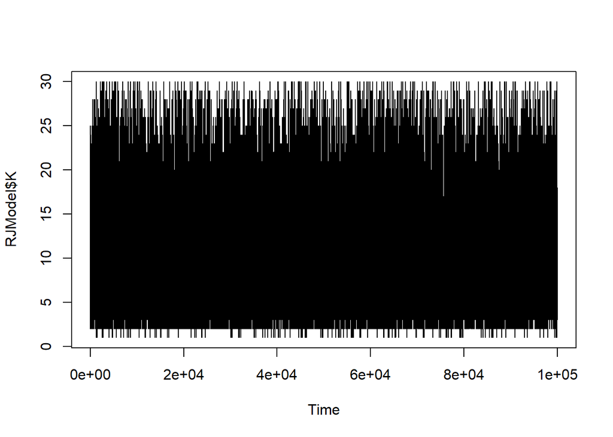

```r
ts.plot(RJModel$K)
```

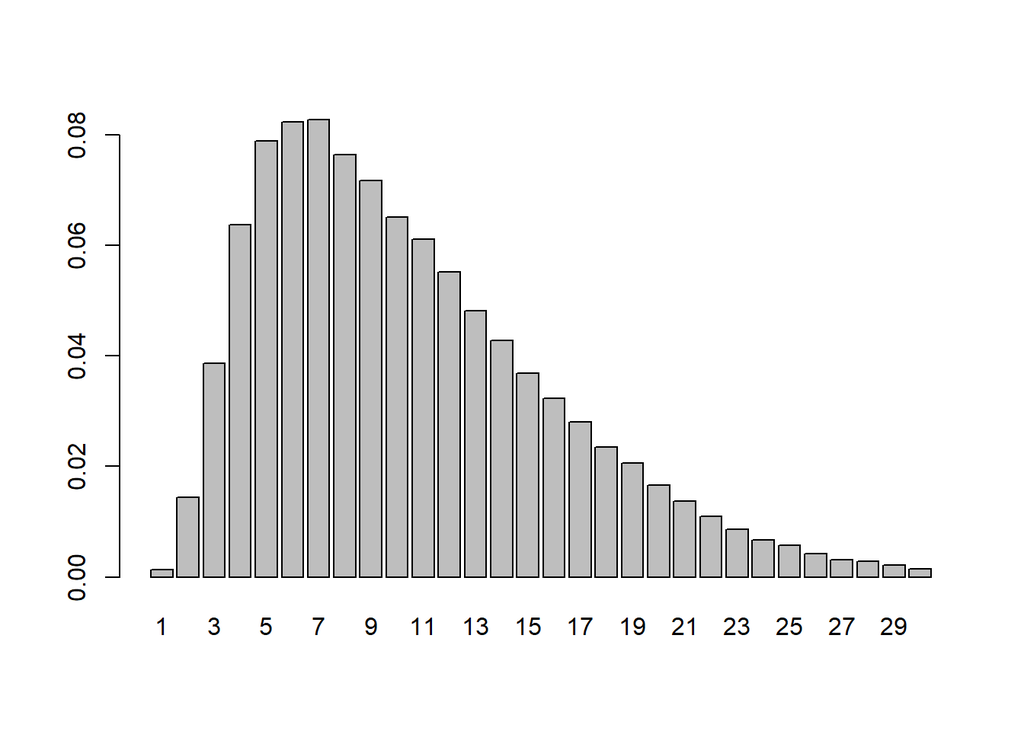

```r
barplot(prop.table(table(RJModel$K)))
```

# Conclusions gathered from the preprocessing and the plots

## Summary on the steps taken:

- Erase useless columns and change of the names of the columns
- Erase empty values and outliers
- Erase all 0s columns
- Make histograms to se the distributions of the variables
- Make scatterplots to see the relationships between the data

## Several interesting conclusions were obtained from the previously computed steps:

- The distributions are not clearly following any distribution but are kind of right-skewed.
- There seems to be a kind of linear relationship between the variables but it seems to be more pronounced between Followers and Following.

# Division in train and test sets

Firstly, we need to divide into train and test sets. We will take the 75% of the data for the training test. This is interesting because we can see how the algorithms are doing comparing the results in the test set.

```r
set.seed(25)
nobs=dim(data)[1]
train = 1:round(nobs*0.75)
test=(round(nobs*0.75)+1):nobs
data_train <- data[train,]
data_test <- data[test,]
data_train
```

```
##    Followers Following Close.Friends
## 1        300       300            10
## 2         71       135             0
## 3        377       231            31
## 4        421       540            61
## 5        950      1300            70
## 6       1171      1131            77
## 7        128       341             1
## 8        893       839            20
## 9        894      1164            92
## 11       784       257            38
## 13       847       830            61
## 14       180       112            12
## 15       269       482            13
## 17       160       168            23
```

[output cut: 44 more lines]

# Frequentist approach

```r
fit=lm(Followers ~ Close.Friends + Following, data = data_train)
summary(fit)
```

```
##
## Call:
## lm(formula = Followers ~ Close.Friends + Following, data = data_train)
##
## Residuals:
##     Min      1Q  Median      3Q     Max
## -357.85 -119.13  -48.07  133.89  544.38
##
## Coefficients:
##               Estimate Std. Error t value Pr(>|t|)
## (Intercept)   23.08467   60.56852   0.381 0.704573
## Close.Friends  3.80853    1.07857   3.531 0.000846 ***
## Following      0.59301    0.09069   6.539 2.14e-08 ***
## ---
## Signif. codes:  0 '***' 0.001 '**' 0.01 '*' 0.05 '.' 0.1 ' ' 1
##
## Residual standard error: 208.3 on 55 degrees of freedom
## Multiple R-squared:  0.623,  Adjusted R-squared:  0.6093
## F-statistic: 45.44 on 2 and 55 DF,  p-value: 2.235e-12
```

With the obtained results, it can be seen that both variables are significant for the problem, as their values are below 0.05. However, Following is more relevant (in the scatterplots it could be seen that their linear relationship was more clear, and tgeir correlation is also bigger).

# Bayesian models

## MCMC

In order to solve this problem, as the variable to study is numeric continuous, I will use regression. The model will have the following variable as the one to study and the number of iterations is also defined.

```r
library(MCMCpack)
bayes <- MCMCregress(Followers ~ Close.Friends + Following, data = data_train, burnin= 1000, mcmc = 10000)
summary(bayes)
```

```
##
## Iterations = 1001:11000
## Thinning interval = 1
## Number of chains = 1
## Sample size per chain = 10000
##
## 1. Empirical mean and standard deviation for each variable,
##    plus standard error of the mean:
##
##                    Mean        SD  Naive SE Time-series SE
## (Intercept)   2.288e+01 6.133e+01 6.133e-01      6.170e-01
## Close.Friends 3.788e+00 1.105e+00 1.105e-02      1.105e-02
## Following     5.939e-01 9.192e-02 9.192e-04      9.192e-04
## sigma2        4.496e+04 8.953e+03 8.953e+01      9.533e+01
##
## 2. Quantiles for each variable:
##
##                     2.5%        25%       50%       75%     97.5%
## (Intercept)     -95.0799   -17.8103    22.514 6.369e+01   143.365
## Close.Friends     1.6136     3.0507     3.785 4.519e+00     5.975
## Following         0.4128     0.5331     0.594 6.557e-01     0.774
## sigma2        30903.1972 38533.4855 43741.933 4.993e+04 65432.227
```

```r
confint(fit,level=.95)
```

```
##                     2.5 %      97.5 %
## (Intercept)   -98.2973649 144.4666970
## Close.Friends   1.6470252   5.9700415
## Following       0.4112675   0.7747608
```

Again, studying the confidence intervals, it can be seen that both variables are significant as their values for the 95% CI do not include number 0.

Now, let’s study the convergence and the autocorrelation to see if more repetitions should be added or some thinning should be applied. This will be done with the ts plot and the acf.

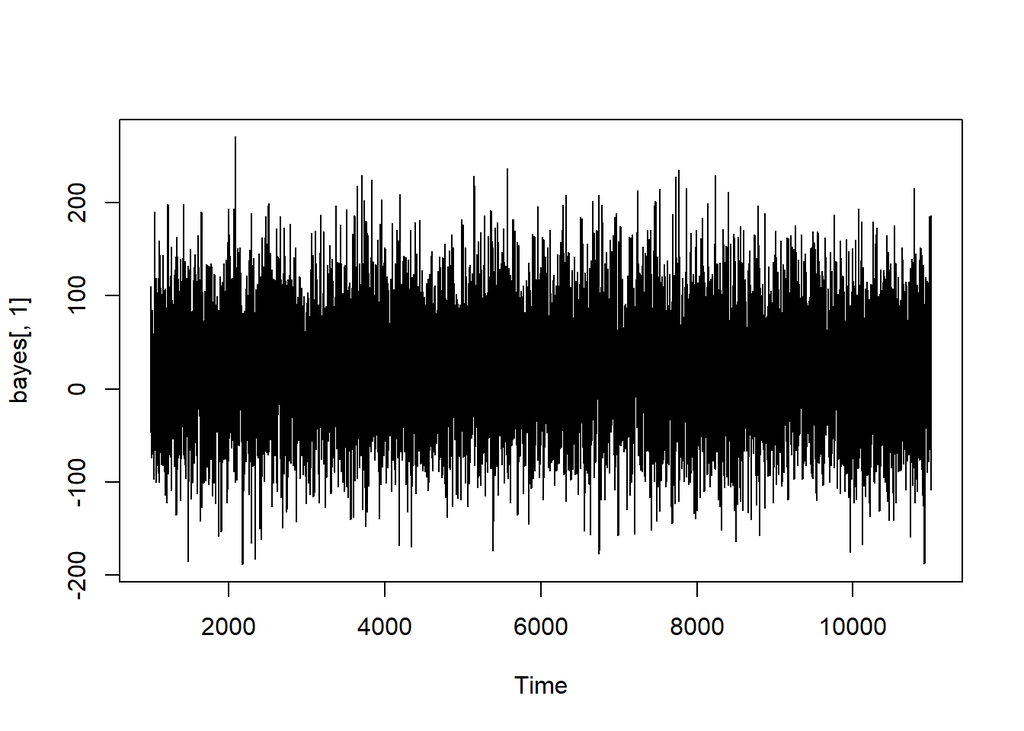

```r
ts.plot(bayes[,1])
```

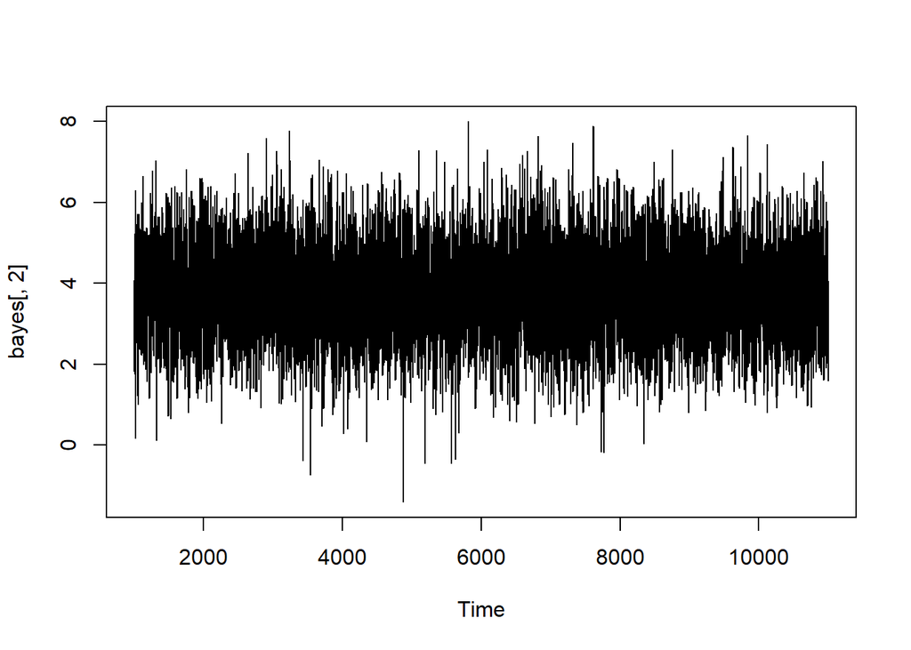

```r
ts.plot(bayes[,2])
```

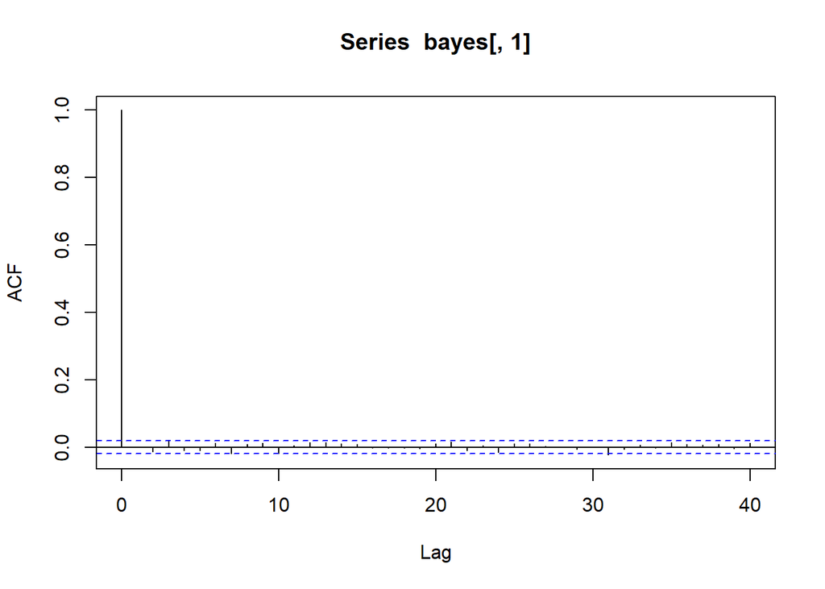

```r
acf(bayes[,1])
```

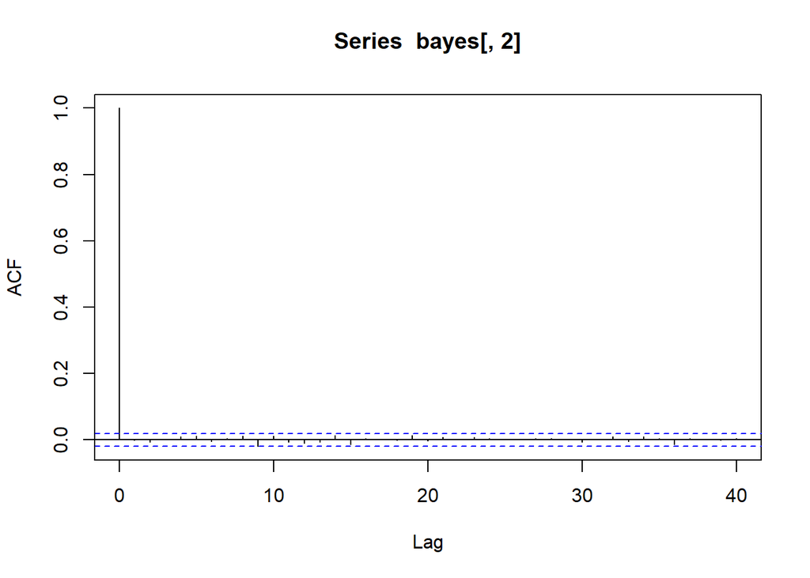

```r
acf(bayes[,2])
```

The results show that the algorithm converges and there is no autocorrelation so no further changes must be applied to the model.

## Study the parameters

```r
# Extract coefficients from the Bayesian model
beta <- bayes[, 1:3]  # Exclude the intercept (if present) from the coefficients
sigma2 <- bayes[, 4]

# Calculate the mean coefficients
mean.beta <- apply(beta, 2, mean)
mean.beta
```

```
##   (Intercept) Close.Friends     Following
##    22.8823777     3.7882839     0.5938838
```

```r
mean(sigma2)
```

```
## [1] 44964.73
```

```r
apply(beta, 2, median)
```

```
##   (Intercept) Close.Friends     Following
##    22.5135241     3.7848765     0.5939582
```

```r
median(sigma2)
```

```
## [1] 43741.93
```

```r
apply(beta, 2, quantile, c(0.025, 0.975))
```

```
##       (Intercept) Close.Friends Following
## 2.5%    -95.07993      1.613590 0.4128378
## 97.5%   143.36478      5.975404 0.7740405
```

*Note that the values may have changed slightly as different iterations may give different results.

Also, with this information we can predict how many followers a user will have based on specific values of close friends and following. Let’s perform an example of a user that has 30 close friends and 500 following.

```r
x.new = c(1, 30, 500)
x.new%*%apply(beta,2,mean)
```

```
##          [,1]
## [1,] 433.4728
```

```r
# Confidence interval
quantile(x.new%*%t(beta),probs=c(0.025,0.975))
```

```
##     2.5%    97.5%
## 374.8664 492.6797
```

```r
# Predictive interval
y.pred=rnorm(dim(beta)[1],x.new%*%t(beta),sqrt(sigma2))
quantile(y.pred,probs=c(0.025,0.975))
```

```
##      2.5%     97.5%
##  13.88693 853.93236
```

Approximately, this user will have 433 followers. In order to make more predictions and see how the model works, we can predict all the values from the test set and plot them with the originals to see how well it is behaving.

## Evaluate with the test set

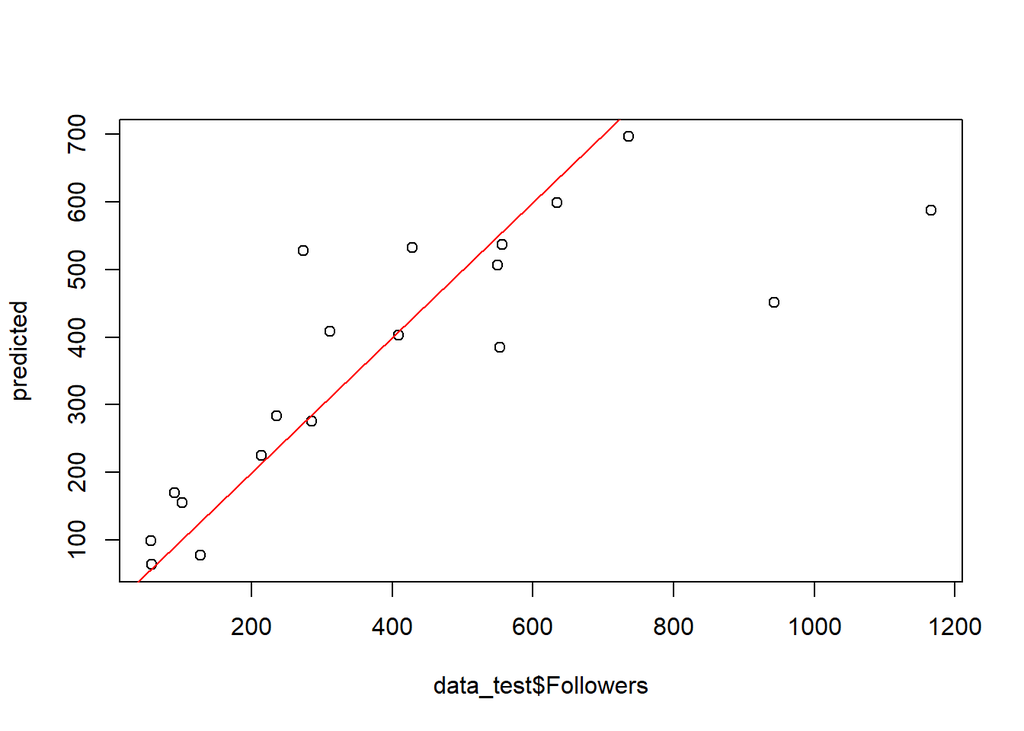

```r
# Prepare predictor variables for the test set
n <- dim(data_test)[1]
X <- cbind(rep(1, n), data_test$Close.Friends, data_test$Following)

# Predict the response variable
predicted <- X %*% mean.beta

# Plot actual vs. predicted values
plot(data_test$Followers, predicted)
abline(0, 1, col = "red")
```

Seeing that the majority of the values are very close to the red line, it can be seen that the model makes a good prediction on the number of followers of the user.

## R2OpenBugs

The same model that was computed using MCMC is now going to be computed in Open Bugs. Following a regression, the normal distribution is used, so we need mu and phi as parameters within the distribution, and mu will depend then on beta and the variables to study.

Also, as in the other model the number of followers of a person with 30 close friends and 500 following, it will also be computed here.

```r
library(R2OpenBUGS)

model <- function(){
  for (i in 1:N) {
    Followers[i] ~ dnorm(mu[i], phi)
    mu[i] <- beta0 + beta1 * Close.Friends[i] + beta2 * Following[i]
  }

  # Priors
  beta0 ~ dnorm(0.0, 1.0E-6)
  beta1 ~ dnorm(0.0, 1.0E-6)
  beta2 ~ dnorm(0.0, 1.0E-6)
  phi ~ dgamma(0.001, 0.001)
  sigma2 <- 1 / phi

  followers.new ~ dnorm(mu.new, phi)
  mu.new <- beta0 + beta1 * close.friends.new + beta2 * following.new
}

N <- length(data_train$Followers)
data <- list(N = N,
             Followers = data_train$Followers,
             Close.Friends = data_train$Close.Friends,
             Following = data_train$Following,
             close.friends.new = 30,
             following.new = 500
)


inits <- function() {list(beta0 = 0, beta1 = 0, beta2 = 0, phi = 0.5, followers.new = 250)}

# Run the model
output <- bugs(data = data, inits = inits,
               parameters.to.save = c("beta0", "beta1", "beta2", "sigma2", "mu.new", "followers.new"), model.file = model,
               n.chains = 1, n.iter = 11000, n.burnin = 1000)

output
```

```
## Inference for Bugs model at "C:/Users/Marina/AppData/Local/Temp/RtmpQDPTLK/model30fc744167aa.txt",
## Current: 1 chains, each with 11000 iterations (first 1000 discarded)
## Cumulative: n.sims = 10000 iterations saved
##                  mean     sd    2.5%     25%     50%     75%   97.5%
## beta0            23.0   60.3   -95.3   -17.2    22.8    62.9   141.0
## beta1             3.8    1.1     1.6     3.1     3.8     4.5     5.9
## beta2             0.6    0.1     0.4     0.5     0.6     0.7     0.8
## sigma2        44744.4 8759.5 30609.2 38530.0 43690.0 49870.0 65100.7
## mu.new          433.8   29.5   376.4   414.2   433.5   453.2   492.7
## followers.new   430.0  216.2    11.4   283.6   431.6   574.5   850.2
## deviance        784.9    2.9   781.3   782.8   784.2   786.3   792.2
##
## DIC info (using the rule, pD = Dbar-Dhat)
## pD = 4.0 and DIC = 788.9
## DIC is an estimate of expected predictive error (lower deviance is better).
```

The output seems similar to the one obtained previously on the other model. The confidence intervals almost coincide, as well as the values of the mean and the standard deviation, what shows that the models are computed correctly, and the conclusions are also correct.

Let’s check that there is no autocorrelation and it converges.

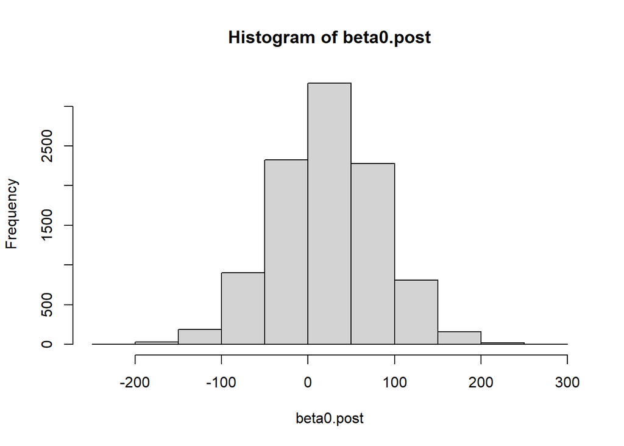

```r
beta0.post <-output$sims.list$beta0
beta1.post <-output$sims.list$beta1
beta2.post <-output$sims.list$beta2

hist(beta0.post)
```

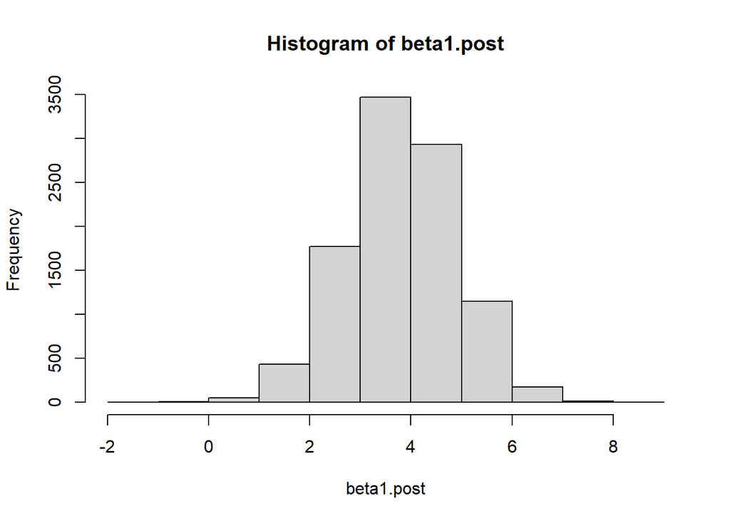

```r
hist(beta1.post)
```

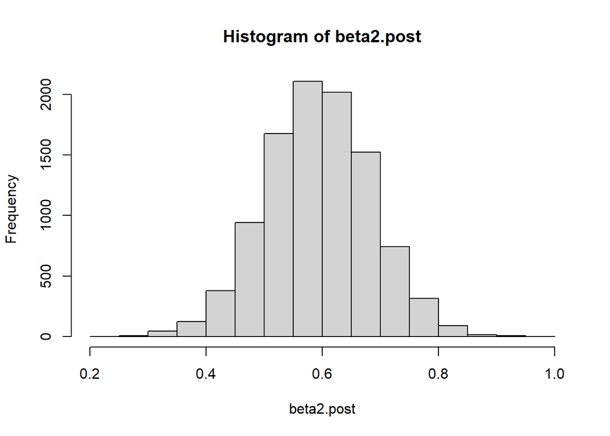

```r
hist(beta2.post)
```

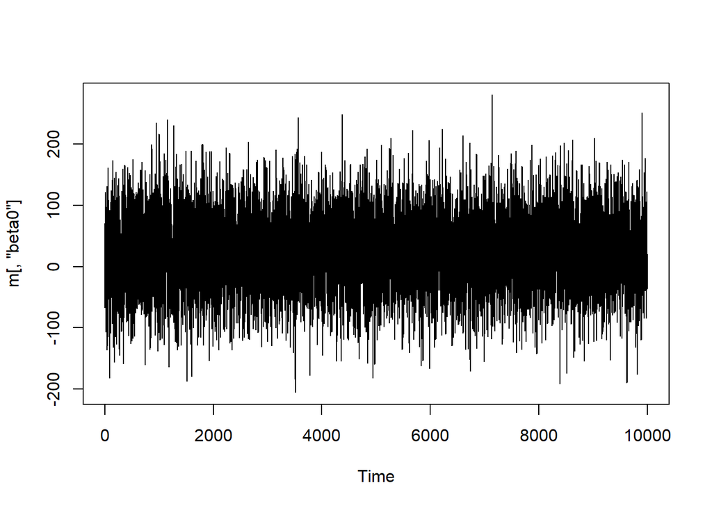

```r
m <- output$sims.matrix
ts.plot(m[,"beta0"])
```

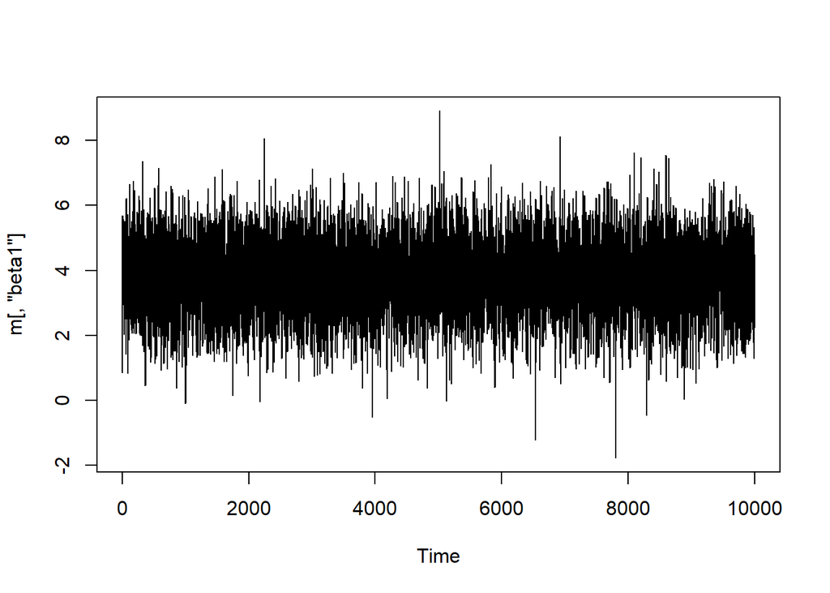

```r
ts.plot(m[,"beta1"])
```

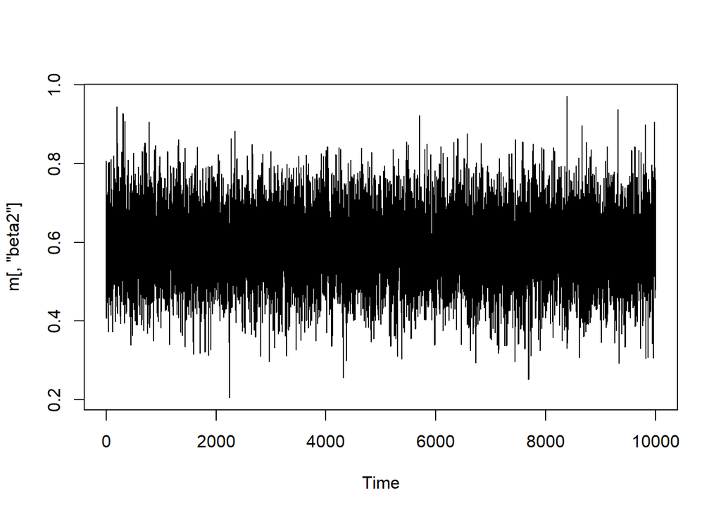

```r
ts.plot(m[,"beta2"])
```

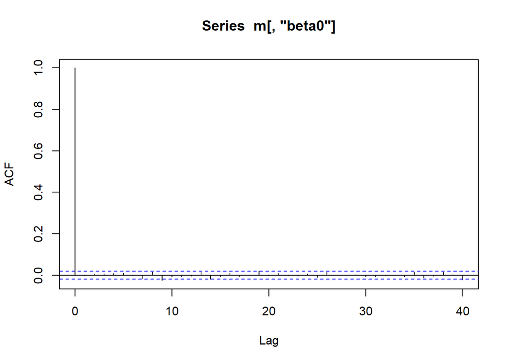

```r
acf(m[,"beta0"])
```

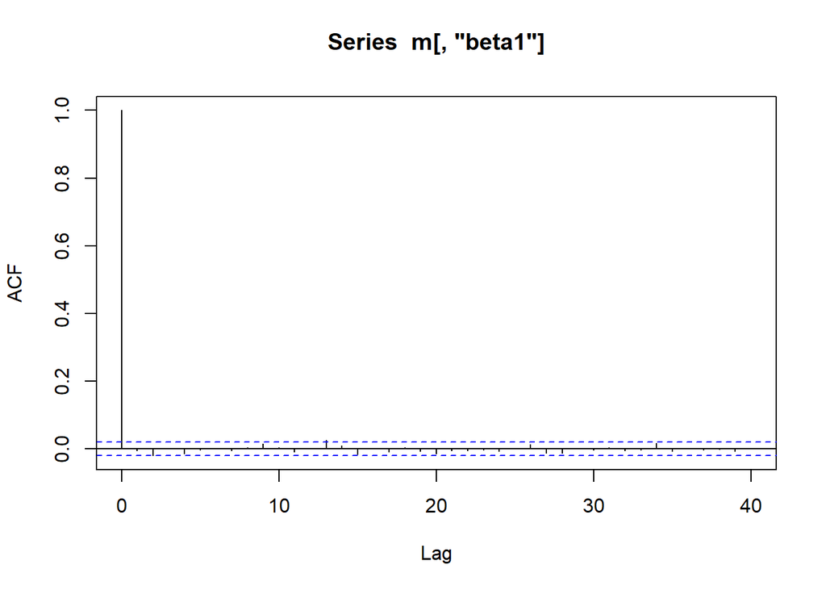

```r
acf(m[,"beta1"])
```

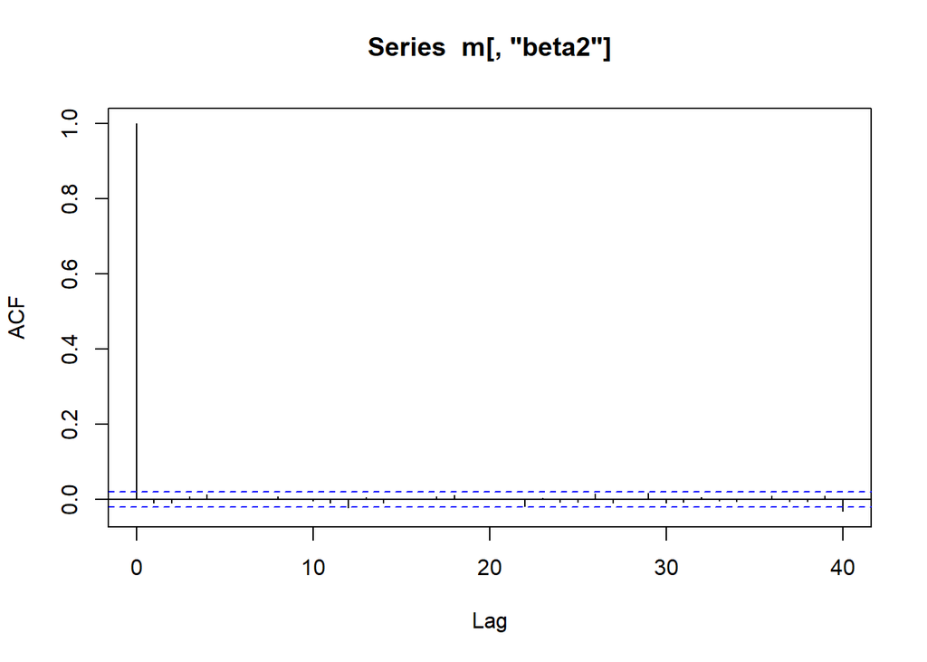

```r
acf(m[,"beta2"])
```

As before, it can be seen that the algorithm converges and there is no autocorrelation. Finally, let’s check the new value of followers.

```r
followers.post <-output$sims.list$followers.new
mean(followers.post)
```

```
## [1] 429.9699
```

It gives approximately 430, what is a very similar value to the one obtained using MCMC.

# Conclusions

Let’s make a summary of all the techniques applied: data preprocessing where iIrrelevant columns were removed, and outliers were handled to ensure data quality, relationships between the variables where scatter plots revealed a linear relationship between followers and the number of accounts followed, and between followers and close friends, analysis of the distribution that showed right-skewedness, brief frequentist analysis in which linear regression confirmed that both close friends and following are significant predictors of followers and the bayesian analysis using both MCMC and OpenBugs that supported the frequentist results, providing credible intervals that further confirmed the significance of both predictors. Also, the results were checked with a test set and were closely related, so the results are robust.

The main insights that have been obtained is that both the number of close friends and following users is relevant and influence in a positive way the number of followers, so if any user wants to grow in that app, a good practice can be to enlarge this two aspects.

In order to make a further analysis and explore other variables, some other instagram features could be included such as the number of posts, if the account is public or private (categorical) or the amount of time a day the user passes on the app. Also, more data would provide better results that would make more precise predictions.